# 4-Horse-colic-다중대응분석

by seung hoon

2020 3 5

데이터 불러오기 3에서 사용한 결측값을 대체한 데이터셋을 따로 저장하여 사용함

```r
library(tidyverse)
data = read_csv("C:/Users/SeungSeungSsi/Desktop/기말프로젝트/Horse/horse_data_행렬도.csv")
```

데이터 타입 바꾸기

```r
data$surgery = as.factor(data$surgery)
data$peripheral_pulse = as.factor(data$peripheral_pulse)
data$mucous_membrane = as.factor(data$mucous_membrane)
data$capillary_refill_time = as.factor(data$capillary_refill_time)
data$pain = as.factor(data$pain)
data$peristalsis = as.factor(data$peristalsis)
#data$abdomen = as.factor(data$abdomen)
data$outcome = as.factor(data$outcome)
data$surgical_lesion = as.factor(data$surgical_lesion)
#data$cp_data = as.factor(data$cp_data)
data$temp_of_extremities = as.factor(data$temp_of_extremities)
data$age = as.factor(data$age)
data$outcome = as.factor(data$outcome)
#data$lesion_location = as.factor(data$lesion_location)
#data$lesion_type = as.factor(data$lesion_type)
data = data[,-1]
```

## 4. 다중대응분석

### 4-1 주성분 행렬도

주성분 행렬도에 이용 가능했던 변수는 연속형 자료였던 rectal_temp, pulse, respiratory_rate, packed_cell_volume 4개가 있었다. 먼저 주성부분분석의 요약은 다음과 같았다.

```r
X <- data[,c("rectal_temp","pulse","respiratory_rate","packed_cell_volume")]
n <- nrow(X)
X_scale = scale(X)
pca.X <- princomp(X_scale, cor=F)
pca.X$scores <- pca.X$scores*sqrt((n-1)/n)

summary(pca.X)
```

```
## Importance of components:
##                           Comp.1    Comp.2    Comp.3    Comp.4
## Standard deviation     1.3487668 0.9370425 0.9204691 0.6649346
## Proportion of Variance 0.4563191 0.2202488 0.2125267 0.1109054
## Cumulative Proportion  0.4563191 0.6765679 0.8890946 1.0000000
```

```r
print(pca.X$loadings)
```

```
##
## Loadings:
##                    Comp.1 Comp.2 Comp.3 Comp.4
## rectal_temp         0.358  0.900  0.248
## pulse               0.622 -0.205        -0.751
## respiratory_rate    0.510        -0.696  0.505
## packed_cell_volume  0.474 -0.385  0.669  0.425
##
##                Comp.1 Comp.2 Comp.3 Comp.4
## SS loadings      1.00   1.00   1.00   1.00
## Proportion Var   0.25   0.25   0.25   0.25
## Cumulative Var   0.25   0.50   0.75   1.00
```

```r
X
```

```
## # A tibble: 299 x 4
##    rectal_temp pulse respiratory_rate packed_cell_volume
##          <dbl> <dbl>            <dbl>              <dbl>
##  1        38.5    66               28                 45
##  2        39.2    88               20                 50
##  3        38.3    40               24                 33
##  4        39.1   164               84                 48
##  5        37.3   104               35                 74
##  6        38.5   112               28                 43
##  7        37.9    48               16                 37
##  8        38.6    60               14                 44
##  9        39.6    80               36                 38
## 10        38.3    90               25                 40
## # ... with 289 more rows
```

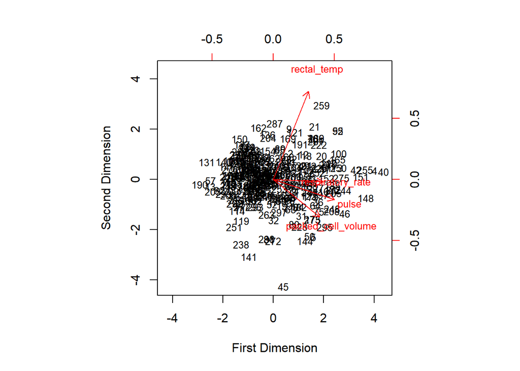

```r
biplot(pca.X, scale=0, cex=0.8, xlab="First Dimension", ylab="Second Dimension")
```

그림을 통해서 pulse, repisratory_rate, packed_cell_volume은 모두 그 차이는 있지만 비슷한 경향 성이 있다는 사실을 알 수 있었다. 주성분 행렬도에 주어진 관측 값들을 다음의 코드를 통해 조 사한 결과 제 1 주성분과 outcome의 관계를 추측 할 수 있었다.

```r
print("제 1 주성분이 0 초과일 때 outcome 의 비율" )
```

```
## [1] "제 1 주성분이 0 초과일 때 outcome 의 비율"
```

```r
dim_1<-data[(pca.X$scores[,1]>0),]
table(dim_1$outcome)/length(dim_1$outcome)
```

```
##
##         1         2         3
## 0.3951613 0.3951613 0.2096774
```

```r
print("제 1 주성분이 0 이하일 때 outcome 의 비율")
```

```
## [1] "제 1 주성분이 0 이하일 때 outcome 의 비율"
```

```r
dim_2<-data[(pca.X$scores[,1]<=0),]
table(dim_2$outcome)/length(dim_2$outcome)
```

```
##
##         1         2         3
## 0.7371429 0.1600000 0.1028571
```

```r
print("전체 outcome 의 비율")
```

```
## [1] "전체 outcome 의 비율"
```

```r
table(data$outcome)/229
```

```
##
##         1         2         3
## 0.7772926 0.3362445 0.1921397
```

제 1 주성분이 0 이하 일 경우, 0 초과일 경우보다 생존 확률이 1.87배 더 높다는 사실을 알 수 있었다. 또한 사망 확률은 0.4배로 더 낮았으며, 안락사 당할 확률은 2배 더 적었다.

```r
print("제 2 주성분이 0 초과일 때 outcome 의 비율 ")
```

```
## [1] "제 2 주성분이 0 초과일 때 outcome 의 비율 "
```

```r
dim_1<-data[(pca.X$scores[,1]>0),]
table(dim_1$outcome)/length(dim_1$outcome)
```

```
##
##         1         2         3
## 0.3951613 0.3951613 0.2096774
```

```r
print("제 2 주성분이 0 이하일 때 outcome 의 비율 ")
```

```
## [1] "제 2 주성분이 0 이하일 때 outcome 의 비율 "
```

```r
dim_2<-data[(pca.X$scores[,1]<=0),]
table(dim_2$outcome)/length(dim_2$outcome)
```

```
##
##         1         2         3
## 0.7371429 0.1600000 0.1028571
```

```r
print("전체 outcome 의 비율 ")
```

```
## [1] "전체 outcome 의 비율 "
```

```r
table(data$outcome)/229
```

```
##
##         1         2         3
## 0.7772926 0.3362445 0.1921397
```